# The Great Recession & Symptoms of Depression in Mexican-origin Families: Considering Youth Perceptions & the Timing of Resilience Factors

Elisa Ugarte

09/14/2021

## Purpose of the project

### Examine changes in parent depressive symptoms and youth perception of economic stress in relation to changes in financial hardship during the Great Recession and its implications for youth’s depressive mood during and two years after the crisis

### Examine its implications for youth’s mental health during and after the great recession, two years later (T3)

### Explore concurrent and prospective promotive effects of family routines and parent-youth relationship quality during and after the recession

### Variables

#### Economic hardship (T1 - T2)

###### Mom’s report of economic hardship: Mean of all subscales - inability to make ends meet, economic adjustments, financial strain, and financial concern

#### Mother & father depression (T1 - T2)

###### MASQ: Mini mood and anxiety questionnaire: Anhedonic depression

#### Youth’s perception of economic stress (T1 - T2)

###### Multicultural Events for Adolescents scale (MESA): “Events that adolescents experience either daily or on a more or less regular schedule”, economic stress subscale

#### Youth depressive mood (T2 - T3)

###### EATQ (Early adolescent temperament questionnaire): Depressive mood (unpleasant affect and lowered mood, loss of enjoyment and interest in activities)

#### Promotive factors (T2)

###### Family routines scale: Homework monitoring, daily schedule, regular activities, adult at home, bed/dinner routines.

###### Composite of relationship quality: Based on quality of relationship with mother, father, and warmth. Relationship quality has two informants, parent and child:

###### BARY - Warmth: Child self report of maternal warmth

###### BARY - Warmth: Child self report of paternal warmth

###### Relationship quality: Mom - Dad - Child report of relationship quality

### This script

#### In one model, it examines:

#### 1. Latent change score from T1 to T2 (Before to the recession): Changes in financial hardship, mother and father depression, and youth perception of economic stress.

#### 2. Whether changes in financial hardship are related to changes in parental depression and youth perception of economic stress, and interrelations between depression and youth perceptions.

#### 3. Concurrent and prospective associations between these changes and youth depression and fear during and after the recession.

###### Bootstraping of standard errors based on 5000 samples was performed to deal with non-normality (Hancock & Liu, 2012).

### T-tests to explore cohort differences

#### CFP has two consecutive cohorts, sampled 1 year apart. Cohort 2 was interviewed closer to the Great Recession.

```
    Welch Two Sample t-test

data:  dat$c05dep by dat$C00COHORT
t = 2.2832, df = 220.59, p-value = 0.02337
alternative hypothesis: true difference in means is not equal to 0
95 percent confidence interval:
 0.01745829 0.23774300
sample estimates:
mean in group 1 mean in group 2
       1.791725        1.664124
```

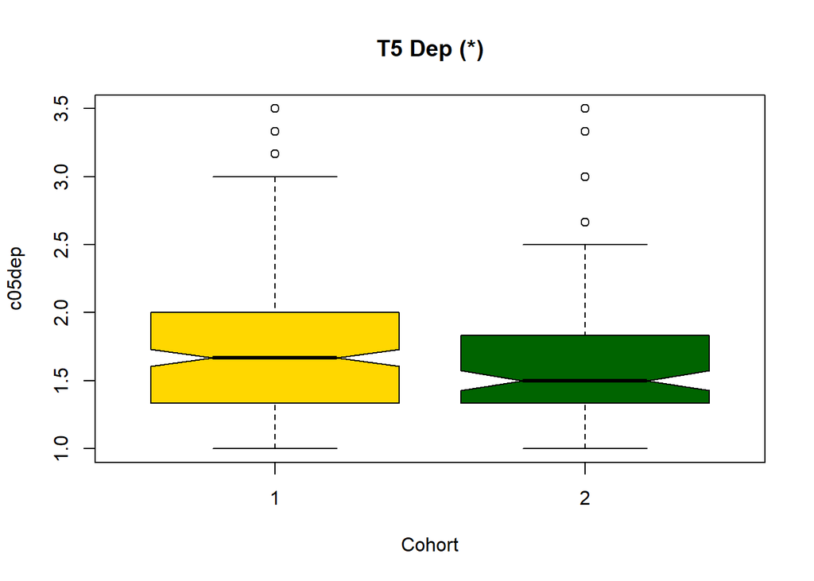

```
    Welch Two Sample t-test

data:  dat$c03dep by dat$C00COHORT
t = 0.9458, df = 205.81, p-value = 0.3454
alternative hypothesis: true difference in means is not equal to 0
95 percent confidence interval:
 -0.05346289  0.15205342
sample estimates:
mean in group 1 mean in group 2
       1.762801        1.713506
```

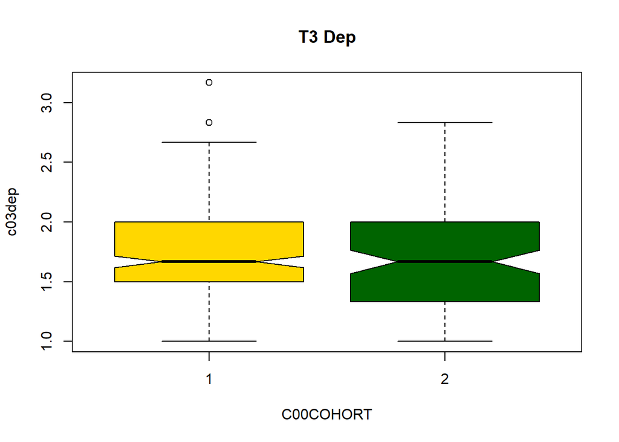

```
    Welch Two Sample t-test

data:  dat$M01ECHD by dat$C00COHORT
t = -1.7292, df = 189.91, p-value = 0.0854
alternative hypothesis: true difference in means is not equal to 0
95 percent confidence interval:
 -0.20678994  0.01359346
sample estimates:
mean in group 1 mean in group 2
       1.907631        2.004229
```

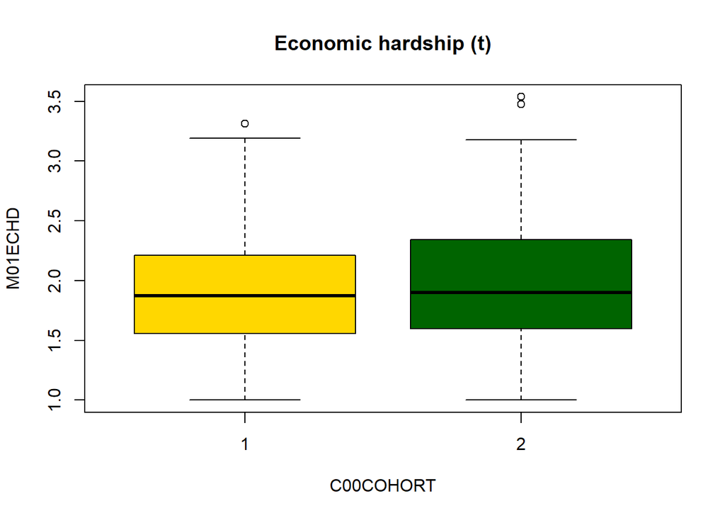

```
    Welch Two Sample t-test

data:  dat$m01masqad by dat$C00COHORT
t = -1.138, df = 196.7, p-value = 0.2565
alternative hypothesis: true difference in means is not equal to 0
95 percent confidence interval:
 -0.22515037  0.06038224
sample estimates:
mean in group 1 mean in group 2
       1.826580        1.908964
```

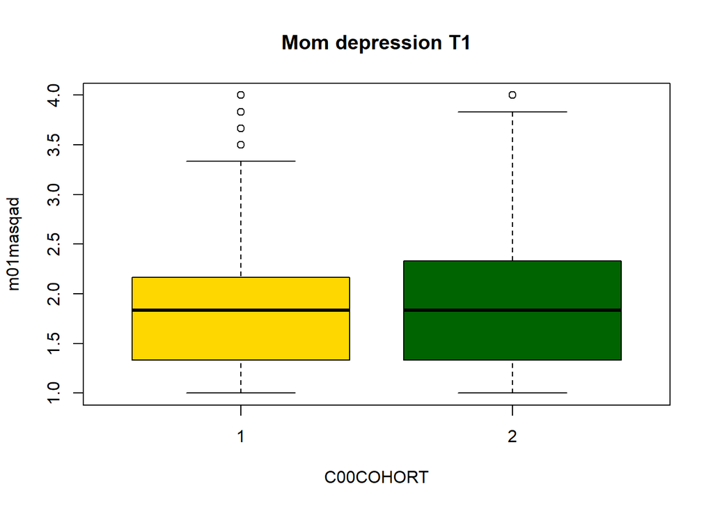

```
    Welch Two Sample t-test

data:  dat$d01masqad by dat$C00COHORT
t = 0.74246, df = 186.9, p-value = 0.4587
alternative hypothesis: true difference in means is not equal to 0
95 percent confidence interval:
 -0.09622933  0.21237602
sample estimates:
mean in group 1 mean in group 2
       1.728571        1.670498
```

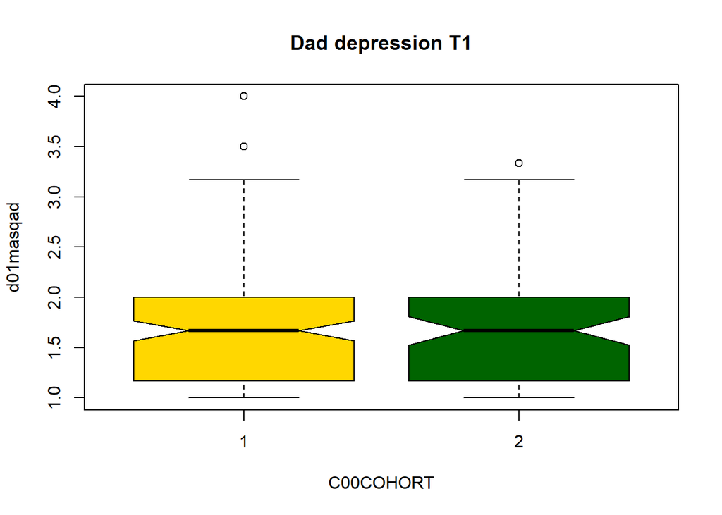

```
    Welch Two Sample t-test

data:  dat$c01meses by dat$C00COHORT
t = -4.1952, df = 185.87, p-value = 4.218e-05
alternative hypothesis: true difference in means is not equal to 0
95 percent confidence interval:
 -0.10437925 -0.03760876
sample estimates:
mean in group 1 mean in group 2
     0.09248575      0.16347976
```

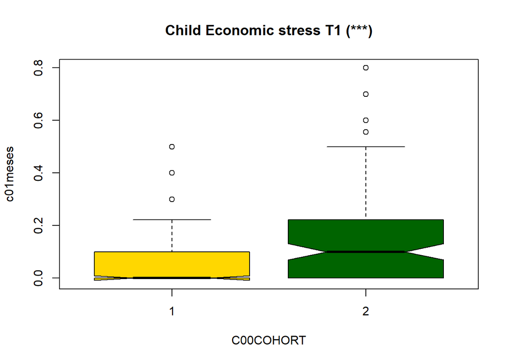

```
    Welch Two Sample t-test

data:  dat$w03DCPosRel by dat$C00COHORT
t = -0.096364, df = 193.29, p-value = 0.9233
alternative hypothesis: true difference in means is not equal to 0
95 percent confidence interval:
 -0.1272411  0.1153867
sample estimates:
mean in group 1 mean in group 2
       3.280669        3.286596
```

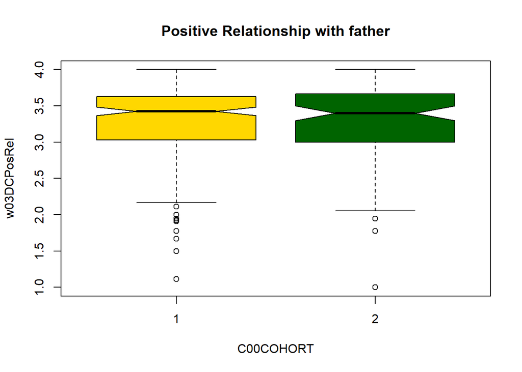

```
    Welch Two Sample t-test

data:  dat$w03MCPosRel by dat$C00COHORT
t = 0.18163, df = 214.79, p-value = 0.856
alternative hypothesis: true difference in means is not equal to 0
95 percent confidence interval:
 -0.07349189  0.08841060
sample estimates:
mean in group 1 mean in group 2
        3.43507         3.42761
```

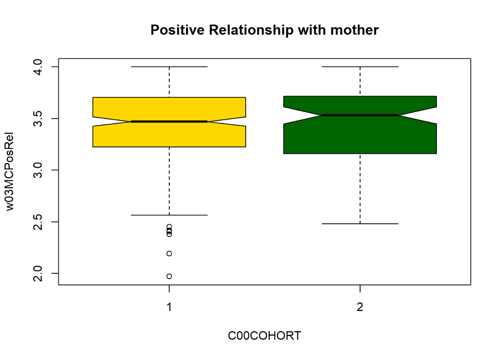

```
    Welch Two Sample t-test

data:  dat$m03FRou by dat$C00COHORT
t = -1.0812, df = 215.31, p-value = 0.2808
alternative hypothesis: true difference in means is not equal to 0
95 percent confidence interval:
 -0.14342464  0.04181195
sample estimates:
mean in group 1 mean in group 2
       2.951657        3.002463
```

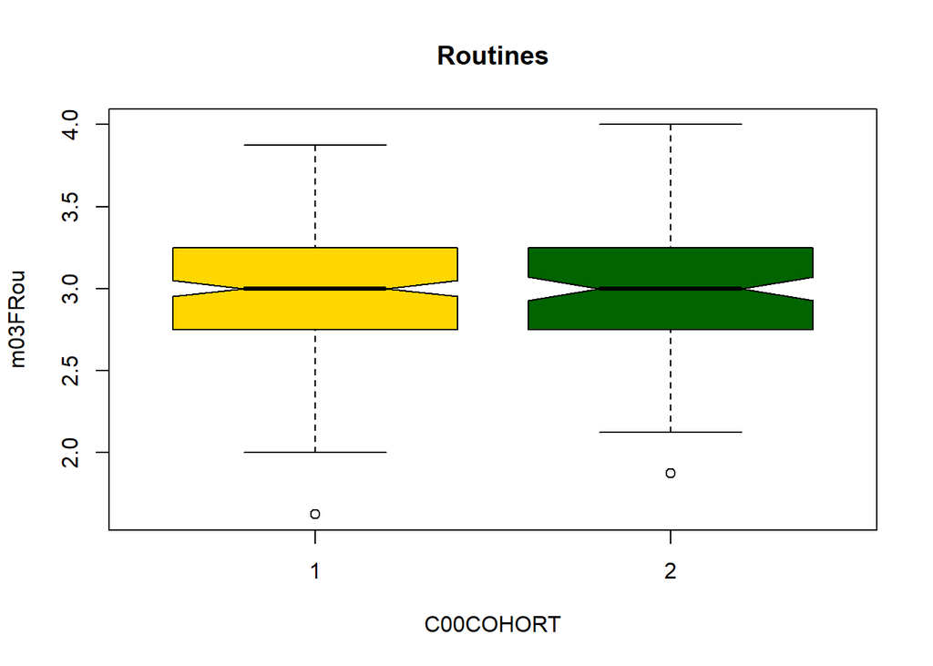

### Descriptives

```
##             vars   n  mean   sd median trimmed  mad   min   max range  skew
## M01ECHD        1 432  1.93 0.49   1.90    1.91 0.51  1.00  3.54  2.54  0.48
## M03ECHD        2 379  2.14 0.52   2.16    2.14 0.61  1.00  3.50  2.50  0.02
## sex            3 446  1.49 0.50   1.00    1.49 0.00  1.00  2.00  1.00  0.03
## m01masqad      4 425  1.85 0.64   1.83    1.80 0.74  1.00  4.00  3.00  0.68
## m03masqad      5 377  1.95 0.62   2.00    1.92 0.49  1.00  4.00  3.00  0.53
## d01masqad      6 262  1.71 0.61   1.67    1.63 0.74  1.00  4.00  3.00  0.94
## d03masqad      7 249  1.77 0.60   1.67    1.72 0.74  1.00  4.00  3.00  0.74
## m03FRou        8 379  2.97 0.42   3.00    2.97 0.37  1.62  4.00  2.38 -0.18
## c01meses       9 441  0.11 0.15   0.10    0.09 0.15  0.00  0.80  0.80  1.50
## c03meses      10 377  0.13 0.14   0.10    0.11 0.15  0.00  0.80  0.80  1.14
## c03dep        11 379  1.75 0.45   1.67    1.72 0.49  1.00  3.17  2.17  0.50
## c05dep        12 404  1.75 0.52   1.67    1.71 0.49  1.00  3.50  2.50  0.90
## w03DCPosRel   13 350  3.28 0.52   3.41    3.35 0.43  1.00  4.00  3.00 -1.39
## w03MCPosRel   14 379  3.43 0.36   3.48    3.46 0.37  1.97  4.00  2.03 -0.80
## W1Age         15 446 10.84 0.52  10.81   10.82 0.50  9.77 12.70  2.92  0.46
## W3Age         16 379 12.81 0.50  12.75   12.78 0.45 11.82 15.25  3.43  0.86
## W5Age         17 405 14.75 0.50  14.72   14.72 0.50 13.74 16.27  2.52  0.52
## C00COHORT*    18 446  1.29 0.45   1.00    1.24 0.00  1.00  2.00  1.00  0.91
## cohort        19 446  1.29 0.45   1.00    1.24 0.00  1.00  2.00  1.00  0.91
##             kurtosis   se
## M01ECHD        -0.11 0.02
## M03ECHD        -0.72 0.03
## sex            -2.00 0.02
## m01masqad       0.29 0.03
## m03masqad       0.24 0.03
## d01masqad       0.54 0.04
## d03masqad       0.57 0.04
## m03FRou        -0.11 0.02
## c01meses        2.22 0.01
## c03meses        1.27 0.01
## c03dep         -0.25 0.02
## c05dep          0.66 0.03
## w03DCPosRel     2.30 0.03
## w03MCPosRel     0.56 0.02
## W1Age           0.21 0.02
## W3Age           1.43 0.03
## W5Age          -0.09 0.02
## C00COHORT*     -1.17 0.02
## cohort         -1.17 0.02
```

### Latent change SEM

```
##
## Model Test User Model:
##
##   Test statistic                               122.739
##   Degrees of freedom                                78
##   P-value                                        0.001
##
## User Model versus Baseline Model:
##
##   Comparative Fit Index (CFI)                    0.937
##   Tucker-Lewis Index (TLI)                       0.903
##
## Root Mean Square Error of Approximation:
##
##   RMSEA                                          0.036
```

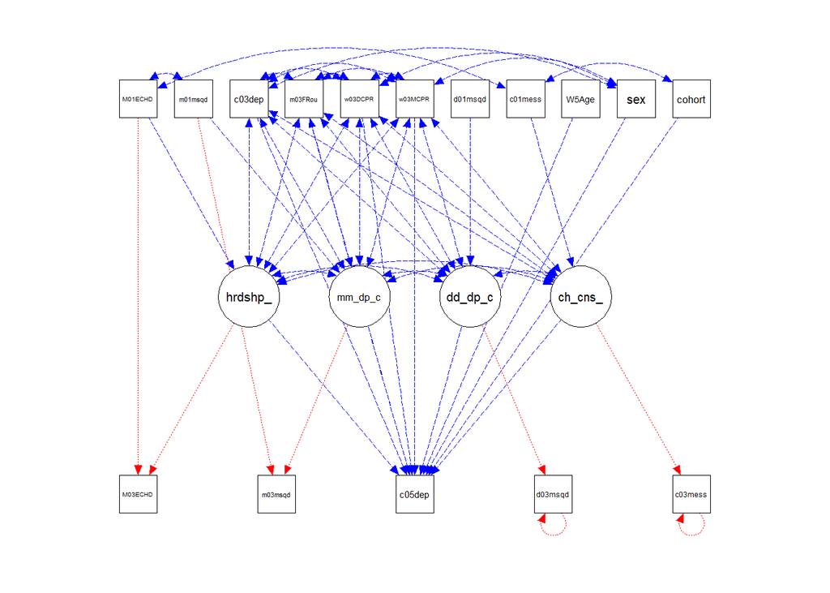

```
## lavaan 0.6-7 ended normally after 146 iterations
##
##   Estimator                                         ML
##   Optimization method                           NLMINB
##   Number of free parameters                         74
##
##   Number of observations                           446
##   Number of missing patterns                        37
##
## Model Test User Model:
##
##   Test statistic                               122.739
##   Degrees of freedom                                78
##   P-value (Chi-square)                           0.001
##
## Model Test Baseline Model:
##
##   Test statistic                               828.944
##   Degrees of freedom                               120
##   P-value                                        0.000
##
## User Model versus Baseline Model:
##
##   Comparative Fit Index (CFI)                    0.937
##   Tucker-Lewis Index (TLI)                       0.903
##
## Loglikelihood and Information Criteria:
##
##   Loglikelihood user model (H0)              -3107.854
##   Loglikelihood unrestricted model (H1)      -3046.485
##
##   Akaike (AIC)                                6363.708
##   Bayesian (BIC)                              6667.132
##   Sample-size adjusted Bayesian (BIC)         6432.287
##
## Root Mean Square Error of Approximation:
##
##   RMSEA                                          0.036
##   90 Percent confidence interval - lower         0.023
##   90 Percent confidence interval - upper         0.048
```

[output cut: 158 more lines]

```
##     sex               0.250    0.000  774.634    0.000    0.250    1.000
##     c03dep            0.206    0.014   14.776    0.000    0.206    1.000
##     cohort            0.207    0.009   22.751    0.000    0.207    1.000
##
## R-Square:
##                    Estimate
##     M03ECHD           1.000
##     hardship_ch       0.161
##     m03masqad         1.000
##     mom_dep_ch        0.322
##     d03masqad         1.000
##     dad_dep_ch        0.103
##     c03meses          1.000
##     ch_ecnstrss_ch    0.074
##     c05dep            0.255
```

```
##                 lhs op              rhs    est    se       z pvalue ci.lower
## 1       hardship_ch =~          M03ECHD  1.000 0.000      NA     NA    1.000
## 2           M03ECHD  ~          M01ECHD  1.000 0.000      NA     NA    1.000
## 3           M03ECHD ~~          M03ECHD  0.000 0.000      NA     NA    0.000
## 4       hardship_ch  ~          M01ECHD -0.378 0.043  -8.746  0.000   -0.460
## 5           M01ECHD ~~          M01ECHD  0.240 0.016  15.070  0.000    0.209
## 6       hardship_ch ~~      hardship_ch  0.178 0.012  14.280  0.000    0.153
## 7       hardship_ch ~1                   0.940 0.089  10.529  0.000    0.766
## 8           M01ECHD ~1                   1.935 0.024  81.790  0.000    1.889
## 9        mom_dep_ch =~        m03masqad  1.000 0.000      NA     NA    1.000
## 10        m03masqad  ~        m01masqad  1.000 0.000      NA     NA    1.000
## 11        m03masqad ~~        m03masqad  0.000 0.000      NA     NA    0.000
## 12       mom_dep_ch  ~        m01masqad -0.588 0.048 -12.200  0.000   -0.685
## 13        m01masqad ~~        m01masqad  0.409 0.029  13.923  0.000    0.354
## 14       mom_dep_ch ~~       mom_dep_ch  0.298 0.023  12.901  0.000    0.252
```

[output cut: 181 more lines]

## Extra: Path model of results

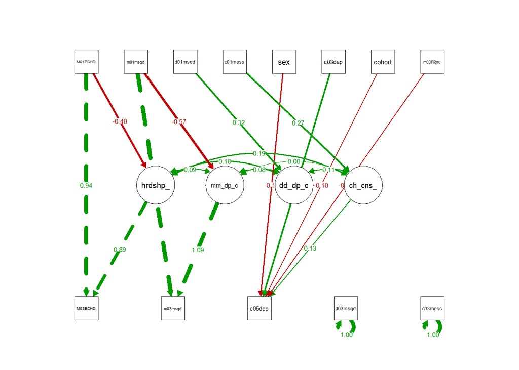